# Risk Factor Analysis

## Outcome Variable

**Outcome Variable:** whz

## Predictor Variables

**Intervention Variable:** mbmi

**Adjustment Set:**

- arm
- W_mage
- W_fage
- meducyrs
- feducyrs
- single
- brthmon
- W_gagebrth
- W_birthwt
- W_birthlen
- vagbrth
- delta_W_mage
- delta_W_fage
- delta_meducyrs
- delta_feducyrs
- delta_single
- delta_brthmon
- delta_W_gagebrth
- delta_W_birthwt
- delta_W_birthlen
- delta_vagbrth

## Stratifying Variables

The analysis was stratified on these variable(s):

- agecat
- studyid
- country

## Data Summary

| agecat | studyid | country | mbmi | n_cell | n |
| --- | --- | --- | --- | --- | --- |
| 6 months | ki0047075b-MAL-ED | BANGLADESH | Normal weight | 209 | 241 |
| 6 months | ki0047075b-MAL-ED | BANGLADESH | Underweight | 32 | 241 |
| 6 months | ki0047075b-MAL-ED | BRAZIL | Normal weight | 199 | 208 |
| 6 months | ki0047075b-MAL-ED | BRAZIL | Underweight | 9 | 208 |
| 6 months | ki0047075b-MAL-ED | INDIA | Normal weight | 186 | 235 |
| 6 months | ki0047075b-MAL-ED | INDIA | Underweight | 49 | 235 |
| 6 months | ki0047075b-MAL-ED | NEPAL | Normal weight | 236 | 236 |
| 6 months | ki0047075b-MAL-ED | NEPAL | Underweight | 0 | 236 |
| 6 months | ki0047075b-MAL-ED | PERU | Normal weight | 267 | 272 |
| 6 months | ki0047075b-MAL-ED | PERU | Underweight | 5 | 272 |
| 6 months | ki0047075b-MAL-ED | SOUTH AFRICA | Normal weight | 242 | 249 |
| 6 months | ki0047075b-MAL-ED | SOUTH AFRICA | Underweight | 7 | 249 |
| 6 months | ki0047075b-MAL-ED | TANZANIA, UNITED REPUBLIC OF | Normal weight | 233 | 247 |
| 6 months | ki0047075b-MAL-ED | TANZANIA, UNITED REPUBLIC OF | Underweight | 14 | 247 |
| 6 months | ki1000304b-SAS-CompFeed | INDIA | Normal weight | 921 | 1225 |
| 6 months | ki1000304b-SAS-CompFeed | INDIA | Underweight | 304 | 1225 |
| 6 months | ki1017093-NIH-Birth | BANGLADESH | Normal weight | 443 | 536 |
| 6 months | ki1017093-NIH-Birth | BANGLADESH | Underweight | 93 | 536 |
| 6 months | ki1017093b-PROVIDE | BANGLADESH | Normal weight | 480 | 581 |
| 6 months | ki1017093b-PROVIDE | BANGLADESH | Underweight | 101 | 581 |
| 6 months | ki1017093c-NIH-Crypto | BANGLADESH | Normal weight | 648 | 715 |
| 6 months | ki1017093c-NIH-Crypto | BANGLADESH | Underweight | 67 | 715 |
| 6 months | ki1066203-TanzaniaChild2 | TANZANIA, UNITED REPUBLIC OF | Normal weight | 1949 | 1982 |
| 6 months | ki1066203-TanzaniaChild2 | TANZANIA, UNITED REPUBLIC OF | Underweight | 33 | 1982 |
| 6 months | ki1119695-PROBIT | BELARUS | Normal weight | 12519 | 13024 |
| 6 months | ki1119695-PROBIT | BELARUS | Underweight | 505 | 13024 |
| 6 months | ki1126311-ZVITAMBO | ZIMBABWE | Normal weight | 6726 | 7087 |
| 6 months | ki1126311-ZVITAMBO | ZIMBABWE | Underweight | 361 | 7087 |
| 6 months | ki1148112-LCNI-5 | MALAWI | Normal weight | 691 | 836 |
| 6 months | ki1148112-LCNI-5 | MALAWI | Underweight | 145 | 836 |
| 24 months | ki0047075b-MAL-ED | BANGLADESH | Normal weight | 183 | 212 |
| 24 months | ki0047075b-MAL-ED | BANGLADESH | Underweight | 29 | 212 |
| 24 months | ki0047075b-MAL-ED | BRAZIL | Normal weight | 162 | 168 |
| 24 months | ki0047075b-MAL-ED | BRAZIL | Underweight | 6 | 168 |
| 24 months | ki0047075b-MAL-ED | INDIA | Normal weight | 180 | 226 |
| 24 months | ki0047075b-MAL-ED | INDIA | Underweight | 46 | 226 |
| 24 months | ki0047075b-MAL-ED | NEPAL | Normal weight | 228 | 228 |
| 24 months | ki0047075b-MAL-ED | NEPAL | Underweight | 0 | 228 |
| 24 months | ki0047075b-MAL-ED | PERU | Normal weight | 197 | 201 |
| 24 months | ki0047075b-MAL-ED | PERU | Underweight | 4 | 201 |
| 24 months | ki0047075b-MAL-ED | SOUTH AFRICA | Normal weight | 227 | 234 |
| 24 months | ki0047075b-MAL-ED | SOUTH AFRICA | Underweight | 7 | 234 |
| 24 months | ki0047075b-MAL-ED | TANZANIA, UNITED REPUBLIC OF | Normal weight | 203 | 214 |
| 24 months | ki0047075b-MAL-ED | TANZANIA, UNITED REPUBLIC OF | Underweight | 11 | 214 |
| 24 months | ki1017093-NIH-Birth | BANGLADESH | Normal weight | 348 | 428 |
| 24 months | ki1017093-NIH-Birth | BANGLADESH | Underweight | 80 | 428 |
| 24 months | ki1017093b-PROVIDE | BANGLADESH | Normal weight | 477 | 577 |
| 24 months | ki1017093b-PROVIDE | BANGLADESH | Underweight | 100 | 577 |
| 24 months | ki1017093c-NIH-Crypto | BANGLADESH | Normal weight | 471 | 514 |
| 24 months | ki1017093c-NIH-Crypto | BANGLADESH | Underweight | 43 | 514 |
| 24 months | ki1066203-TanzaniaChild2 | TANZANIA, UNITED REPUBLIC OF | Normal weight | 6 | 6 |
| 24 months | ki1066203-TanzaniaChild2 | TANZANIA, UNITED REPUBLIC OF | Underweight | 0 | 6 |
| 24 months | ki1119695-PROBIT | BELARUS | Normal weight | 3800 | 3941 |
| 24 months | ki1119695-PROBIT | BELARUS | Underweight | 141 | 3941 |
| 24 months | ki1126311-ZVITAMBO | ZIMBABWE | Normal weight | 334 | 359 |
| 24 months | ki1126311-ZVITAMBO | ZIMBABWE | Underweight | 25 | 359 |
| 24 months | ki1148112-LCNI-5 | MALAWI | Normal weight | 467 | 561 |
| 24 months | ki1148112-LCNI-5 | MALAWI | Underweight | 94 | 561 |

The following strata were considered:

- agecat: 24 months, studyid: ki0047075b-MAL-ED, country: BANGLADESH
- agecat: 24 months, studyid: ki0047075b-MAL-ED, country: BRAZIL
- agecat: 24 months, studyid: ki0047075b-MAL-ED, country: INDIA
- agecat: 24 months, studyid: ki0047075b-MAL-ED, country: NEPAL
- agecat: 24 months, studyid: ki0047075b-MAL-ED, country: PERU
- agecat: 24 months, studyid: ki0047075b-MAL-ED, country: SOUTH AFRICA
- agecat: 24 months, studyid: ki0047075b-MAL-ED, country: TANZANIA, UNITED REPUBLIC OF
- agecat: 24 months, studyid: ki1017093-NIH-Birth, country: BANGLADESH
- agecat: 24 months, studyid: ki1017093b-PROVIDE, country: BANGLADESH
- agecat: 24 months, studyid: ki1017093c-NIH-Crypto, country: BANGLADESH
- agecat: 24 months, studyid: ki1066203-TanzaniaChild2, country: TANZANIA, UNITED REPUBLIC OF
- agecat: 24 months, studyid: ki1119695-PROBIT, country: BELARUS
- agecat: 24 months, studyid: ki1126311-ZVITAMBO, country: ZIMBABWE
- agecat: 24 months, studyid: ki1148112-LCNI-5, country: MALAWI
- agecat: 6 months, studyid: ki0047075b-MAL-ED, country: BANGLADESH
- agecat: 6 months, studyid: ki0047075b-MAL-ED, country: BRAZIL
- agecat: 6 months, studyid: ki0047075b-MAL-ED, country: INDIA
- agecat: 6 months, studyid: ki0047075b-MAL-ED, country: NEPAL
- agecat: 6 months, studyid: ki0047075b-MAL-ED, country: PERU
- agecat: 6 months, studyid: ki0047075b-MAL-ED, country: SOUTH AFRICA
- agecat: 6 months, studyid: ki0047075b-MAL-ED, country: TANZANIA, UNITED REPUBLIC OF
- agecat: 6 months, studyid: ki1000304b-SAS-CompFeed, country: INDIA
- agecat: 6 months, studyid: ki1017093-NIH-Birth, country: BANGLADESH
- agecat: 6 months, studyid: ki1017093b-PROVIDE, country: BANGLADESH
- agecat: 6 months, studyid: ki1017093c-NIH-Crypto, country: BANGLADESH
- agecat: 6 months, studyid: ki1066203-TanzaniaChild2, country: TANZANIA, UNITED REPUBLIC OF
- agecat: 6 months, studyid: ki1119695-PROBIT, country: BELARUS
- agecat: 6 months, studyid: ki1126311-ZVITAMBO, country: ZIMBABWE
- agecat: 6 months, studyid: ki1148112-LCNI-5, country: MALAWI

### Dropped Strata

Some strata were dropped due to rare outcomes:

- agecat: 6 months, studyid: ki0047075b-MAL-ED, country: NEPAL
- agecat: 24 months, studyid: ki0047075b-MAL-ED, country: NEPAL
- agecat: 24 months, studyid: ki0047075b-MAL-ED, country: PERU
- agecat: 24 months, studyid: ki1066203-TanzaniaChild2, country: TANZANIA, UNITED REPUBLIC OF

## Methods Detail

We’re interested in the causal parameters $E[Y_a]$ for all values of $a \in \mathcal{A}$. These parameters represent the mean outcome if, possibly contrary to fact, we intervened to set all units to have $A=a$. Under the randomization and positivity assumptions, these are identified by the statistical parameters $\psi_a=E_W[E_{Y|A,W}(Y|A=a,W)]$. In addition, we’re interested in the mean of $Y$, $E[Y]$ under no intervention (the observed mean). We will estimate these parameters by using SuperLearner to fit the relevant likelihood factors – $E_{Y|A,W}(Y|A=a,W)$ and $p(A=a|W)$, and then updating our likelihood fit using a joint TMLE.

For unadjusted analyses ($W=\{\}$), initial likelihoods were estimated using Lrnr_glm to estimate the simple $E(Y|A)$ and Lrnr_mean to estimate $p(A)$. For adjusted analyses, a small library containing Lrnr_glmnet, Lrnr_xgboost, and Lrnr_mean was used.

Having estimated these parameters, we will then use the delta method to estimate relative risks and attributable risks relative to a prespecified baseline level of $A$.

# Results Detail

## Results Plots

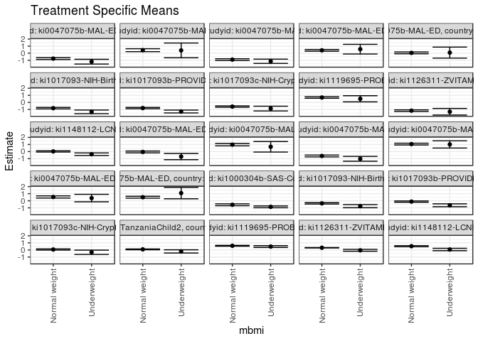

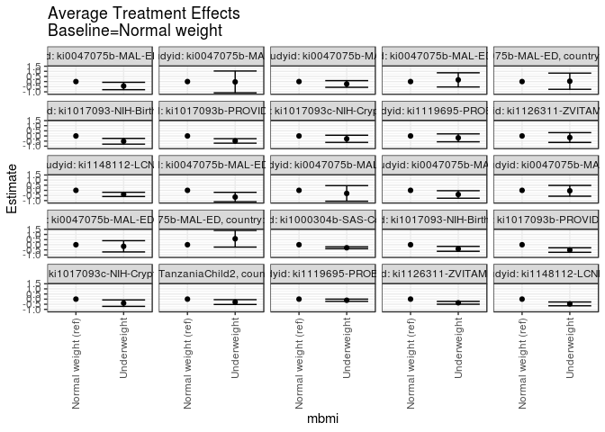

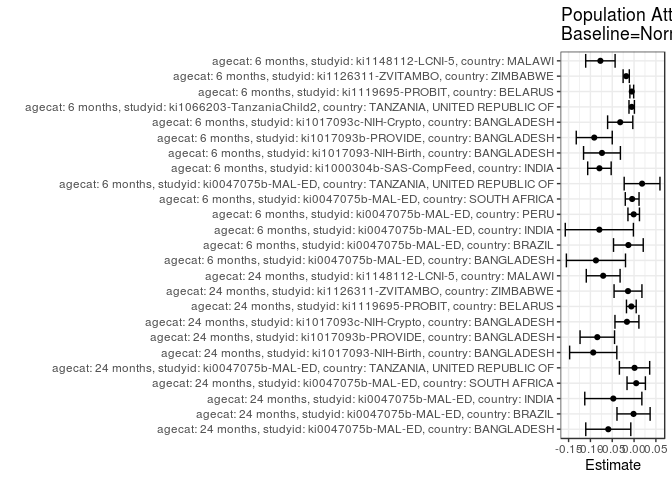

## Results Table

### Parameter: TSM

| agecat | studyid | country | intervention_level | baseline_level | estimate | ci_lower | ci_upper |
| --- | --- | --- | --- | --- | --- | --- | --- |
| 6 months | ki0047075b-MAL-ED | BANGLADESH | Normal weight | NA | -0.0524711 | -0.1812548 | 0.0763126 |
| 6 months | ki0047075b-MAL-ED | BANGLADESH | Underweight | NA | -0.7066539 | -1.1483762 | -0.2649316 |
| 6 months | ki0047075b-MAL-ED | BRAZIL | Normal weight | NA | 0.9775209 | 0.8091090 | 1.1459329 |
| 6 months | ki0047075b-MAL-ED | BRAZIL | Underweight | NA | 0.6764815 | -0.0674862 | 1.4204491 |
| 6 months | ki0047075b-MAL-ED | INDIA | Normal weight | NA | -0.6192655 | -0.7511193 | -0.4874117 |
| 6 months | ki0047075b-MAL-ED | INDIA | Underweight | NA | -1.0213156 | -1.3613930 | -0.6812381 |
| 6 months | ki0047075b-MAL-ED | PERU | Normal weight | NA | 1.0571910 | 0.9326684 | 1.1817136 |
| 6 months | ki0047075b-MAL-ED | PERU | Underweight | NA | 1.0130000 | 0.5008674 | 1.5251326 |
| 6 months | ki0047075b-MAL-ED | SOUTH AFRICA | Normal weight | NA | 0.5333953 | 0.3757046 | 0.6910860 |
| 6 months | ki0047075b-MAL-ED | SOUTH AFRICA | Underweight | NA | 0.3785714 | -0.1478585 | 0.9050014 |
| 6 months | ki0047075b-MAL-ED | TANZANIA, UNITED REPUBLIC OF | Normal weight | NA | 0.4987018 | 0.3623266 | 0.6350771 |
| 6 months | ki0047075b-MAL-ED | TANZANIA, UNITED REPUBLIC OF | Underweight | NA | 1.0819216 | 0.2811803 | 1.8826630 |
| 6 months | ki1000304b-SAS-CompFeed | INDIA | Normal weight | NA | -0.5647696 | -0.6966524 | -0.4328869 |
| 6 months | ki1000304b-SAS-CompFeed | INDIA | Underweight | NA | -0.8594544 | -0.9885709 | -0.7303378 |
| 6 months | ki1017093-NIH-Birth | BANGLADESH | Normal weight | NA | -0.3654138 | -0.4627110 | -0.2681165 |
| 6 months | ki1017093-NIH-Birth | BANGLADESH | Underweight | NA | -0.7656062 | -0.9840327 | -0.5471798 |
| 6 months | ki1017093b-PROVIDE | BANGLADESH | Normal weight | NA | -0.1167740 | -0.2083596 | -0.0251884 |
| 6 months | ki1017093b-PROVIDE | BANGLADESH | Underweight | NA | -0.6360685 | -0.8359634 | -0.4361736 |
| 6 months | ki1017093c-NIH-Crypto | BANGLADESH | Normal weight | NA | 0.0614941 | -0.0204982 | 0.1434865 |
| 6 months | ki1017093c-NIH-Crypto | BANGLADESH | Underweight | NA | -0.3295403 | -0.6342617 | -0.0248188 |
| 6 months | ki1066203-TanzaniaChild2 | TANZANIA, UNITED REPUBLIC OF | Normal weight | NA | 0.0829180 | 0.0285662 | 0.1372698 |
| 6 months | ki1066203-TanzaniaChild2 | TANZANIA, UNITED REPUBLIC OF | Underweight | NA | -0.2053698 | -0.4329255 | 0.0221860 |
| 6 months | ki1119695-PROBIT | BELARUS | Normal weight | NA | 0.5882405 | 0.5301707 | 0.6463104 |
| 6 months | ki1119695-PROBIT | BELARUS | Underweight | NA | 0.4774802 | 0.3499578 | 0.6050025 |
| 6 months | ki1126311-ZVITAMBO | ZIMBABWE | Normal weight | NA | 0.3108071 | 0.2822518 | 0.3393624 |
| 6 months | ki1126311-ZVITAMBO | ZIMBABWE | Underweight | NA | -0.0484522 | -0.1834904 | 0.0865860 |
| 6 months | ki1148112-LCNI-5 | MALAWI | Normal weight | NA | 0.5286604 | 0.4501666 | 0.6071542 |
| 6 months | ki1148112-LCNI-5 | MALAWI | Underweight | NA | 0.0626908 | -0.1055453 | 0.2309269 |
| 24 months | ki0047075b-MAL-ED | BANGLADESH | Normal weight | NA | -0.7617605 | -0.8916175 | -0.6319035 |
| 24 months | ki0047075b-MAL-ED | BANGLADESH | Underweight | NA | -1.1955068 | -1.5319669 | -0.8590468 |
| 24 months | ki0047075b-MAL-ED | BRAZIL | Normal weight | NA | 0.4294444 | 0.2224555 | 0.6364334 |
| 24 months | ki0047075b-MAL-ED | BRAZIL | Underweight | NA | 0.3966667 | -0.6451983 | 1.4385316 |
| 24 months | ki0047075b-MAL-ED | INDIA | Normal weight | NA | -0.9050325 | -1.0288061 | -0.7812589 |
| 24 months | ki0047075b-MAL-ED | INDIA | Underweight | NA | -1.1391207 | -1.4401456 | -0.8380958 |
| 24 months | ki0047075b-MAL-ED | SOUTH AFRICA | Normal weight | NA | 0.4046696 | 0.2835400 | 0.5257992 |
| 24 months | ki0047075b-MAL-ED | SOUTH AFRICA | Underweight | NA | 0.5700000 | -0.1123856 | 1.2523856 |
| 24 months | ki0047075b-MAL-ED | TANZANIA, UNITED REPUBLIC OF | Normal weight | NA | 0.0489960 | -0.0780188 | 0.1760109 |
| 24 months | ki0047075b-MAL-ED | TANZANIA, UNITED REPUBLIC OF | Underweight | NA | 0.0838848 | -0.6956746 | 0.8634443 |
| 24 months | ki1017093-NIH-Birth | BANGLADESH | Normal weight | NA | -0.8180323 | -0.9214500 | -0.7146145 |
| 24 months | ki1017093-NIH-Birth | BANGLADESH | Underweight | NA | -1.3380788 | -1.5965355 | -1.0796220 |
| 24 months | ki1017093b-PROVIDE | BANGLADESH | Normal weight | NA | -0.8022830 | -0.8919780 | -0.7125881 |
| 24 months | ki1017093b-PROVIDE | BANGLADESH | Underweight | NA | -1.2887453 | -1.4902066 | -1.0872841 |
| 24 months | ki1017093c-NIH-Crypto | BANGLADESH | Normal weight | NA | -0.5940150 | -0.6931770 | -0.4948530 |
| 24 months | ki1017093c-NIH-Crypto | BANGLADESH | Underweight | NA | -0.8741927 | -1.2097490 | -0.5386363 |
| 24 months | ki1119695-PROBIT | BELARUS | Normal weight | NA | 0.6932100 | 0.5832282 | 0.8031919 |
| 24 months | ki1119695-PROBIT | BELARUS | Underweight | NA | 0.5084521 | 0.0739864 | 0.9429177 |
| 24 months | ki1126311-ZVITAMBO | ZIMBABWE | Normal weight | NA | -1.1671099 | -1.2811286 | -1.0530913 |
| 24 months | ki1126311-ZVITAMBO | ZIMBABWE | Underweight | NA | -1.3218026 | -1.7870433 | -0.8565619 |
| 24 months | ki1148112-LCNI-5 | MALAWI | Normal weight | NA | 0.0237852 | -0.0658814 | 0.1134518 |
| 24 months | ki1148112-LCNI-5 | MALAWI | Underweight | NA | -0.3714323 | -0.5567978 | -0.1860668 |

### Parameter: E(Y)

| agecat | studyid | country | intervention_level | baseline_level | estimate | ci_lower | ci_upper |
| --- | --- | --- | --- | --- | --- | --- | --- |
| 6 months | ki0047075b-MAL-ED | BANGLADESH | NA | NA | -0.1397960 | -0.2688682 | -0.0107238 |
| 6 months | ki0047075b-MAL-ED | BRAZIL | NA | NA | 0.9644952 | 0.7999744 | 1.1290160 |
| 6 months | ki0047075b-MAL-ED | INDIA | NA | NA | -0.6987943 | -0.8241325 | -0.5734561 |
| 6 months | ki0047075b-MAL-ED | PERU | NA | NA | 1.0563787 | 0.9342938 | 1.1784635 |
| 6 months | ki0047075b-MAL-ED | SOUTH AFRICA | NA | NA | 0.5290428 | 0.3750394 | 0.6830463 |
| 6 months | ki0047075b-MAL-ED | TANZANIA, UNITED REPUBLIC OF | NA | NA | 0.5170513 | 0.3872178 | 0.6468847 |
| 6 months | ki1000304b-SAS-CompFeed | INDIA | NA | NA | -0.6441020 | -0.7710827 | -0.5171213 |
| 6 months | ki1017093-NIH-Birth | BANGLADESH | NA | NA | -0.4389101 | -0.5279432 | -0.3498771 |
| 6 months | ki1017093b-PROVIDE | BANGLADESH | NA | NA | -0.2079891 | -0.2925599 | -0.1234183 |
| 6 months | ki1017093c-NIH-Crypto | BANGLADESH | NA | NA | 0.0297622 | -0.0491685 | 0.1086930 |
| 6 months | ki1066203-TanzaniaChild2 | TANZANIA, UNITED REPUBLIC OF | NA | NA | 0.0775172 | 0.0241750 | 0.1308595 |
| 6 months | ki1119695-PROBIT | BELARUS | NA | NA | 0.5829956 | 0.5247249 | 0.6412663 |
| 6 months | ki1126311-ZVITAMBO | ZIMBABWE | NA | NA | 0.2928094 | 0.2648167 | 0.3208020 |
| 6 months | ki1148112-LCNI-5 | MALAWI | NA | NA | 0.4515431 | 0.3802415 | 0.5228446 |
| 24 months | ki0047075b-MAL-ED | BANGLADESH | NA | NA | -0.8208255 | -0.9429246 | -0.6987264 |
| 24 months | ki0047075b-MAL-ED | BRAZIL | NA | NA | 0.4282738 | 0.2252365 | 0.6313111 |
| 24 months | ki0047075b-MAL-ED | INDIA | NA | NA | -0.9525664 | -1.0684455 | -0.8366872 |
| 24 months | ki0047075b-MAL-ED | SOUTH AFRICA | NA | NA | 0.4096154 | 0.2902946 | 0.5289362 |
| 24 months | ki0047075b-MAL-ED | TANZANIA, UNITED REPUBLIC OF | NA | NA | 0.0500935 | -0.0748234 | 0.1750103 |
| 24 months | ki1017093-NIH-Birth | BANGLADESH | NA | NA | -0.9115790 | -1.0095022 | -0.8136559 |
| 24 months | ki1017093b-PROVIDE | BANGLADESH | NA | NA | -0.8864991 | -0.9695215 | -0.8034768 |
| 24 months | ki1017093c-NIH-Crypto | BANGLADESH | NA | NA | -0.6103502 | -0.7050157 | -0.5156847 |
| 24 months | ki1119695-PROBIT | BELARUS | NA | NA | 0.6869754 | 0.5725638 | 0.8013869 |
| 24 months | ki1126311-ZVITAMBO | ZIMBABWE | NA | NA | -1.1810028 | -1.2914599 | -1.0705456 |
| 24 months | ki1148112-LCNI-5 | MALAWI | NA | NA | -0.0469519 | -0.1290932 | 0.0351895 |

### Parameter: ATE

| agecat | studyid | country | intervention_level | baseline_level | estimate | ci_lower | ci_upper |
| --- | --- | --- | --- | --- | --- | --- | --- |
| 6 months | ki0047075b-MAL-ED | BANGLADESH | Normal weight | Normal weight | 0.0000000 | 0.0000000 | 0.0000000 |
| 6 months | ki0047075b-MAL-ED | BANGLADESH | Underweight | Normal weight | -0.6541828 | -1.1146353 | -0.1937303 |
| 6 months | ki0047075b-MAL-ED | BRAZIL | Normal weight | Normal weight | 0.0000000 | 0.0000000 | 0.0000000 |
| 6 months | ki0047075b-MAL-ED | BRAZIL | Underweight | Normal weight | -0.3010395 | -1.0638307 | 0.4617517 |
| 6 months | ki0047075b-MAL-ED | INDIA | Normal weight | Normal weight | 0.0000000 | 0.0000000 | 0.0000000 |
| 6 months | ki0047075b-MAL-ED | INDIA | Underweight | Normal weight | -0.4020501 | -0.7676467 | -0.0364534 |
| 6 months | ki0047075b-MAL-ED | PERU | Normal weight | Normal weight | 0.0000000 | 0.0000000 | 0.0000000 |
| 6 months | ki0047075b-MAL-ED | PERU | Underweight | Normal weight | -0.0441910 | -0.5712448 | 0.4828628 |
| 6 months | ki0047075b-MAL-ED | SOUTH AFRICA | Normal weight | Normal weight | 0.0000000 | 0.0000000 | 0.0000000 |
| 6 months | ki0047075b-MAL-ED | SOUTH AFRICA | Underweight | Normal weight | -0.1548239 | -0.7043645 | 0.3947167 |
| 6 months | ki0047075b-MAL-ED | TANZANIA, UNITED REPUBLIC OF | Normal weight | Normal weight | 0.0000000 | 0.0000000 | 0.0000000 |
| 6 months | ki0047075b-MAL-ED | TANZANIA, UNITED REPUBLIC OF | Underweight | Normal weight | 0.5832198 | -0.2300769 | 1.3965165 |
| 6 months | ki1000304b-SAS-CompFeed | INDIA | Normal weight | Normal weight | 0.0000000 | 0.0000000 | 0.0000000 |
| 6 months | ki1000304b-SAS-CompFeed | INDIA | Underweight | Normal weight | -0.2946847 | -0.3867869 | -0.2025826 |
| 6 months | ki1017093-NIH-Birth | BANGLADESH | Normal weight | Normal weight | 0.0000000 | 0.0000000 | 0.0000000 |
| 6 months | ki1017093-NIH-Birth | BANGLADESH | Underweight | Normal weight | -0.4001924 | -0.6395893 | -0.1607956 |
| 6 months | ki1017093b-PROVIDE | BANGLADESH | Normal weight | Normal weight | 0.0000000 | 0.0000000 | 0.0000000 |
| 6 months | ki1017093b-PROVIDE | BANGLADESH | Underweight | Normal weight | -0.5192945 | -0.7395355 | -0.2990534 |
| 6 months | ki1017093c-NIH-Crypto | BANGLADESH | Normal weight | Normal weight | 0.0000000 | 0.0000000 | 0.0000000 |
| 6 months | ki1017093c-NIH-Crypto | BANGLADESH | Underweight | Normal weight | -0.3910344 | -0.7066254 | -0.0754434 |
| 6 months | ki1066203-TanzaniaChild2 | TANZANIA, UNITED REPUBLIC OF | Normal weight | Normal weight | 0.0000000 | 0.0000000 | 0.0000000 |
| 6 months | ki1066203-TanzaniaChild2 | TANZANIA, UNITED REPUBLIC OF | Underweight | Normal weight | -0.2882877 | -0.5220978 | -0.0544777 |
| 6 months | ki1119695-PROBIT | BELARUS | Normal weight | Normal weight | 0.0000000 | 0.0000000 | 0.0000000 |
| 6 months | ki1119695-PROBIT | BELARUS | Underweight | Normal weight | -0.1107603 | -0.2198722 | -0.0016485 |
| 6 months | ki1126311-ZVITAMBO | ZIMBABWE | Normal weight | Normal weight | 0.0000000 | 0.0000000 | 0.0000000 |
| 6 months | ki1126311-ZVITAMBO | ZIMBABWE | Underweight | Normal weight | -0.3592593 | -0.4970528 | -0.2214657 |
| 6 months | ki1148112-LCNI-5 | MALAWI | Normal weight | Normal weight | 0.0000000 | 0.0000000 | 0.0000000 |
| 6 months | ki1148112-LCNI-5 | MALAWI | Underweight | Normal weight | -0.4659696 | -0.6521928 | -0.2797464 |
| 24 months | ki0047075b-MAL-ED | BANGLADESH | Normal weight | Normal weight | 0.0000000 | 0.0000000 | 0.0000000 |
| 24 months | ki0047075b-MAL-ED | BANGLADESH | Underweight | Normal weight | -0.4337463 | -0.7948386 | -0.0726540 |
| 24 months | ki0047075b-MAL-ED | BRAZIL | Normal weight | Normal weight | 0.0000000 | 0.0000000 | 0.0000000 |
| 24 months | ki0047075b-MAL-ED | BRAZIL | Underweight | Normal weight | -0.0327778 | -1.0950051 | 1.0294496 |
| 24 months | ki0047075b-MAL-ED | INDIA | Normal weight | Normal weight | 0.0000000 | 0.0000000 | 0.0000000 |
| 24 months | ki0047075b-MAL-ED | INDIA | Underweight | Normal weight | -0.2340882 | -0.5590753 | 0.0908988 |
| 24 months | ki0047075b-MAL-ED | SOUTH AFRICA | Normal weight | Normal weight | 0.0000000 | 0.0000000 | 0.0000000 |
| 24 months | ki0047075b-MAL-ED | SOUTH AFRICA | Underweight | Normal weight | 0.1653304 | -0.5277226 | 0.8583834 |
| 24 months | ki0047075b-MAL-ED | TANZANIA, UNITED REPUBLIC OF | Normal weight | Normal weight | 0.0000000 | 0.0000000 | 0.0000000 |
| 24 months | ki0047075b-MAL-ED | TANZANIA, UNITED REPUBLIC OF | Underweight | Normal weight | 0.0348888 | -0.7561344 | 0.8259120 |
| 24 months | ki1017093-NIH-Birth | BANGLADESH | Normal weight | Normal weight | 0.0000000 | 0.0000000 | 0.0000000 |
| 24 months | ki1017093-NIH-Birth | BANGLADESH | Underweight | Normal weight | -0.5200465 | -0.7985056 | -0.2415874 |
| 24 months | ki1017093b-PROVIDE | BANGLADESH | Normal weight | Normal weight | 0.0000000 | 0.0000000 | 0.0000000 |
| 24 months | ki1017093b-PROVIDE | BANGLADESH | Underweight | Normal weight | -0.4864623 | -0.7044461 | -0.2684785 |
| 24 months | ki1017093c-NIH-Crypto | BANGLADESH | Normal weight | Normal weight | 0.0000000 | 0.0000000 | 0.0000000 |
| 24 months | ki1017093c-NIH-Crypto | BANGLADESH | Underweight | Normal weight | -0.2801777 | -0.6291953 | 0.0688399 |
| 24 months | ki1119695-PROBIT | BELARUS | Normal weight | Normal weight | 0.0000000 | 0.0000000 | 0.0000000 |
| 24 months | ki1119695-PROBIT | BELARUS | Underweight | Normal weight | -0.1847579 | -0.5699617 | 0.2004458 |
| 24 months | ki1126311-ZVITAMBO | ZIMBABWE | Normal weight | Normal weight | 0.0000000 | 0.0000000 | 0.0000000 |
| 24 months | ki1126311-ZVITAMBO | ZIMBABWE | Underweight | Normal weight | -0.1546927 | -0.6341350 | 0.3247497 |
| 24 months | ki1148112-LCNI-5 | MALAWI | Normal weight | Normal weight | 0.0000000 | 0.0000000 | 0.0000000 |
| 24 months | ki1148112-LCNI-5 | MALAWI | Underweight | Normal weight | -0.3952175 | -0.6012385 | -0.1891964 |

### Parameter: PAR

| agecat | studyid | country | intervention_level | baseline_level | estimate | ci_lower | ci_upper |
| --- | --- | --- | --- | --- | --- | --- | --- |
| 6 months | ki0047075b-MAL-ED | BANGLADESH | Normal weight | NA | -0.0873249 | -0.1550436 | -0.0196062 |
| 6 months | ki0047075b-MAL-ED | BRAZIL | Normal weight | NA | -0.0130257 | -0.0470695 | 0.0210180 |
| 6 months | ki0047075b-MAL-ED | INDIA | Normal weight | NA | -0.0795288 | -0.1576029 | -0.0014547 |
| 6 months | ki0047075b-MAL-ED | PERU | Normal weight | NA | -0.0008123 | -0.0140076 | 0.0123830 |
| 6 months | ki0047075b-MAL-ED | SOUTH AFRICA | Normal weight | NA | -0.0043525 | -0.0201263 | 0.0114214 |
| 6 months | ki0047075b-MAL-ED | TANZANIA, UNITED REPUBLIC OF | Normal weight | NA | 0.0183494 | -0.0226348 | 0.0593337 |
| 6 months | ki1000304b-SAS-CompFeed | INDIA | Normal weight | NA | -0.0793324 | -0.1062191 | -0.0524457 |
| 6 months | ki1017093-NIH-Birth | BANGLADESH | Normal weight | NA | -0.0734963 | -0.1157123 | -0.0312804 |
| 6 months | ki1017093b-PROVIDE | BANGLADESH | Normal weight | NA | -0.0912151 | -0.1324384 | -0.0499917 |
| 6 months | ki1017093c-NIH-Crypto | BANGLADESH | Normal weight | NA | -0.0317319 | -0.0606034 | -0.0028604 |
| 6 months | ki1066203-TanzaniaChild2 | TANZANIA, UNITED REPUBLIC OF | Normal weight | NA | -0.0054008 | -0.0116124 | 0.0008109 |
| 6 months | ki1119695-PROBIT | BELARUS | Normal weight | NA | -0.0052449 | -0.0095863 | -0.0009035 |
| 6 months | ki1126311-ZVITAMBO | ZIMBABWE | Normal weight | NA | -0.0179977 | -0.0250910 | -0.0109044 |
| 6 months | ki1148112-LCNI-5 | MALAWI | Normal weight | NA | -0.0771173 | -0.1108114 | -0.0434233 |
| 24 months | ki0047075b-MAL-ED | BANGLADESH | Normal weight | NA | -0.0590650 | -0.1106314 | -0.0074986 |
| 24 months | ki0047075b-MAL-ED | BRAZIL | Normal weight | NA | -0.0011706 | -0.0391185 | 0.0367773 |
| 24 months | ki0047075b-MAL-ED | INDIA | Normal weight | NA | -0.0475339 | -0.1129302 | 0.0178624 |
| 24 months | ki0047075b-MAL-ED | SOUTH AFRICA | Normal weight | NA | 0.0049458 | -0.0160996 | 0.0259912 |
| 24 months | ki0047075b-MAL-ED | TANZANIA, UNITED REPUBLIC OF | Normal weight | NA | 0.0010974 | -0.0335768 | 0.0357717 |
| 24 months | ki1017093-NIH-Birth | BANGLADESH | Normal weight | NA | -0.0935468 | -0.1476119 | -0.0394817 |
| 24 months | ki1017093b-PROVIDE | BANGLADESH | Normal weight | NA | -0.0842161 | -0.1237246 | -0.0447076 |
| 24 months | ki1017093c-NIH-Crypto | BANGLADESH | Normal weight | NA | -0.0163352 | -0.0437546 | 0.0110842 |
| 24 months | ki1119695-PROBIT | BELARUS | Normal weight | NA | -0.0062346 | -0.0173838 | 0.0049145 |
| 24 months | ki1126311-ZVITAMBO | ZIMBABWE | Normal weight | NA | -0.0138928 | -0.0458087 | 0.0180231 |
| 24 months | ki1148112-LCNI-5 | MALAWI | Normal weight | NA | -0.0707370 | -0.1094655 | -0.0320086 |